# Some more analyses for the StatLearn MetaAnalysis

Alexis Black & Christina Bergmann

2/1/2017

## Set-up

This is the same as in the main analyses to create comparable datasets

```
## Loading 'metafor' package (version 1.9-9). For an overview
## and introduction to the package please type: help(metafor).
```

# What could we look at in the future?

- What are some of the potential moderators?
- **familiarization time**
- frequency_balanced (based on cursory look, might be worth exploring)
- ForwardTP_nonword
- number_syllables
- duration_syllables
- **gender**
- Obviously, we won’t have enough power to look at all of these. How do we choose?

# Gender

```r
# Look at Gender
rma_gender=rma.mv(g_calc, g_var_calc, mods=gender, data=db, random = ~ 1|short_cite)
summary(rma_gender)
```

```
##
## Multivariate Meta-Analysis Model (k = 33; method: REML)
##
##   logLik  Deviance       AIC       BIC      AICc
## -36.4379   72.8757   78.8757   83.1777   79.7646
##
## Variance Components:
##
##             estim    sqrt  nlvls  fixed      factor
## sigma^2    0.0143  0.1195     11     no  short_cite
##
## Test for Residual Heterogeneity:
## QE(df = 31) = 124.3061, p-val < .0001
##
## Test of Moderators (coefficient(s) 2):
## QM(df = 1) = 15.3649, p-val < .0001
##
## Model Results:
##
##          estimate      se     zval    pval    ci.lb    ci.ub
## intrcpt    0.6625  0.1799   3.6824  0.0002   0.3099   1.0151  ***
## mods      -1.5075  0.3846  -3.9198  <.0001  -2.2612  -0.7537  ***
##
## ---
## Signif. codes:  0 '***' 0.001 '**' 0.01 '*' 0.05 '.' 0.1 ' ' 1
```

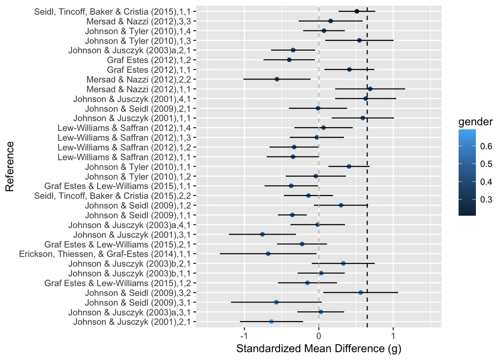

```r
# Let's take a look at this graphically
dat <-
  db %>%
  rename(cite = short_cite,
         yi = g_calc,
         vi = g_var_calc) %>%
  mutate(study_ref = paste(cite, expt_num, same_infant, sep=',')) %>%
  filter(gender >.01) %>%
  arrange(desc(gender))
dat$se = sqrt(dat$vi)
dat$lowerci = (-1.96*dat$se)+dat$yi
dat$upperci = (1.96*dat$se)+dat$yi

ggplot(dat, aes(y=reorder(study_ref, -gender), x=yi, xmin=lowerci, xmax=upperci))+
  geom_point(aes(color = gender))+
  geom_errorbarh(height=.1)+
  scale_x_continuous(limits=c(-1.5,1.5), name='Standardized Mean Difference (g)')+
  ylab('Reference')+
  geom_vline(xintercept=0, color='grey', linetype='dashed')+
  geom_vline(xintercept=0.65, color='black', linetype='dashed')
```

# Different Cues

```r
db_stress <-
  db %>%
  filter(additional_cue == c("stress", "intensity", "duration"))
rma_stress <- rma.mv(g_calc, g_var_calc, mods = ~factor(cue_conflict_TP)-1, data = db_stress, random = ~1|short_cite)
summary(rma_stress)
```

```
##
## Multivariate Meta-Analysis Model (k = 7; method: REML)
##
##   logLik  Deviance       AIC       BIC      AICc
##  -9.4958   18.9916   24.9916   23.8199   48.9916
##
## Variance Components:
##
##             estim    sqrt  nlvls  fixed      factor
## sigma^2    0.4001  0.6325      4     no  short_cite
##
## Test for Residual Heterogeneity:
## QE(df = 5) = 41.1191, p-val < .0001
##
## Test of Moderators (coefficient(s) 1,2):
## QM(df = 2) = 6.1879, p-val = 0.0453
##
## Model Results:
##
##                             estimate      se     zval    pval    ci.lb
## factor(cue_conflict_TP)no    -0.1611  0.3452  -0.4667  0.6407  -0.8377
## factor(cue_conflict_TP)yes    0.3475  0.3397   1.0228  0.3064  -0.3184
##                              ci.ub
## factor(cue_conflict_TP)no   0.5155
## factor(cue_conflict_TP)yes  1.0133
##
## ---
## Signif. codes:  0 '***' 0.001 '**' 0.01 '*' 0.05 '.' 0.1 ' ' 1
```

```r
db_stress <- subset(db, additional_cue == "stress" | additional_cue == "intensity" |
                      additional_cue == "duration" | additional_cue == "prime, stress")
rma_stress <- rma.mv(g_calc, g_var_calc, mods = ~factor(cue_conflict_TP)-1, data = db_stress, random = ~1|short_cite)
summary(rma_stress)
```

```
##
## Multivariate Meta-Analysis Model (k = 24; method: REML)
##
##   logLik  Deviance       AIC       BIC      AICc
## -34.2857   68.5713   74.5713   77.8444   75.9046
##
## Variance Components:
##
##             estim    sqrt  nlvls  fixed      factor
## sigma^2    0.1022  0.3196      5     no  short_cite
##
## Test for Residual Heterogeneity:
## QE(df = 22) = 106.0186, p-val < .0001
##
## Test of Moderators (coefficient(s) 1,2):
## QM(df = 2) = 1.3836, p-val = 0.5007
##
## Model Results:
##
##                             estimate      se    zval    pval    ci.lb
## factor(cue_conflict_TP)no     0.1668  0.1596  1.0454  0.2959  -0.1460
## factor(cue_conflict_TP)yes    0.1000  0.1558  0.6415  0.5212  -0.2055
##                              ci.ub
## factor(cue_conflict_TP)no   0.4796
## factor(cue_conflict_TP)yes  0.4054
##
## ---
## Signif. codes:  0 '***' 0.001 '**' 0.01 '*' 0.05 '.' 0.1 ' ' 1
```

And, not even close. This is something to bring up in the discussion.

# Familiarization Duration

```r
rma_duration <- rma.mv(g_calc, g_var_calc, mods = familiarization_time,
                       data = db,
                       random = ~1|short_cite)
summary(rma_duration)
```

```
##
## Multivariate Meta-Analysis Model (k = 60; method: REML)
##
##   logLik  Deviance       AIC       BIC      AICc
## -76.3890  152.7780  158.7780  164.9594  159.2225
##
## Variance Components:
##
##             estim    sqrt  nlvls  fixed      factor
## sigma^2    0.0523  0.2287     19     no  short_cite
##
## Test for Residual Heterogeneity:
## QE(df = 58) = 301.2042, p-val < .0001
##
## Test of Moderators (coefficient(s) 2):
## QM(df = 1) = 0.0125, p-val = 0.9111
##
## Model Results:
##
##          estimate      se    zval    pval    ci.lb   ci.ub
## intrcpt    0.1056  0.1276  0.8275  0.4079  -0.1445  0.3557
## mods       0.0001  0.0006  0.1117  0.9111  -0.0012  0.0013
##
## ---
## Signif. codes:  0 '***' 0.001 '**' 0.01 '*' 0.05 '.' 0.1 ' ' 1
```

Would be good to look at the interactions of all of these things though …

# Take out the direct reps, bc maybe they skew what would otherwise be a familiarity preference in the rest of the data

```r
db_nonDR <-
  db %>%
  filter(DirectRep == "no")

rma_nonDR <- rma.mv(g_calc, g_var_calc,
                       data = db_nonDR,
                       random = ~1|short_cite)
summary(rma_nonDR)
```

```
##
## Multivariate Meta-Analysis Model (k = 39; method: REML)
##
##   logLik  Deviance       AIC       BIC      AICc
## -42.3793   84.7586   88.7586   92.0338   89.1015
##
## Variance Components:
##
##             estim    sqrt  nlvls  fixed      factor
## sigma^2    0.1357  0.3684     15     no  short_cite
##
## Test for Heterogeneity:
## Q(df = 38) = 204.6059, p-val < .0001
##
## Model Results:
##
## estimate       se     zval     pval    ci.lb    ci.ub
##  -0.0238   0.1023  -0.2331   0.8157  -0.2243   0.1766
##
## ---
## Signif. codes:  0 '***' 0.001 '**' 0.01 '*' 0.05 '.' 0.1 ' ' 1
```

## Future ideas

- I’d like to explore the studies demonstrating a familiarity preference. Are they a unique class? Or is it ‘predictable’ random variation around the mean? Given the outliers in our funnel plots and the extreme degree of heterogeneity, I wonder if there are multiple things going on (rather, I think there are multiple things going on, can we figure out what they are?)